# Final Project

Samantha Petrovich

12/6/2021

```r
library(ggplot2)
library(dplyr)
load("C:/Users/sammi/OneDrive/MSU Stuff/MSUclasses/Fall 2021/PLS 202/Assignments/final.rdata")
```

### Question 1 part 1

There is a variable called migration which is the number of people who entered the country as immigrants. But this is not truly helpful, as bigger countries often experience higher immigration. So, first, create a new variable called immigration_rate that is migration as a percent of total population (in other words: migration / population).

```r
data$immigration_rate <- data$migration/data$population

head(data)
```

```
##     country year highschool      gdp gini literacy migration population alcohol
## 1 Australia 1971         NA 26.26349   NA       NA        NA   12937000      NA
## 2 Australia 1972         NA 26.79402   NA       NA    259531   13177000      NA
## 3 Australia 1973         NA 27.07712   NA       NA        NA   13380000      NA
## 4 Australia 1974         NA 27.48369   NA       NA        NA   13723000      NA
## 5 Australia 1975         NA 27.51387   NA       NA        NA   13893000      NA
## 6 Australia 1976         NA 27.94423   NA       NA        NA   14033000      NA
##   immigration_rate
## 1               NA
## 2       0.01969576
## 3               NA
## 4               NA
## 5               NA
## 6               NA
```

### Question 1 part 2

What was the average (mean) immigration rate in 2017?

```r
data_2017 <- data$immigration_rate[data$year ==2017]
mean(data_2017, na.rm = TRUE)
```

```
## [1] 0.005958742
```

### Question 1 part 3

What was the median immigration rate for Belgium?

```r
data_belgium <- data$immigration_rate[data$country == "Belgium"]

median(data_belgium, na.rm = TRUE)
```

```
## [1] 0.0090629
```

### Question 1 part 4

What was the immigration rate for the United States in 2012?

```r
US_DATA <- data$immigration_rate[data$country == "United States" & data$year == 2012]

US_DATA
```

```
## [1] 0.01581015
```

### Question 2 part 1

I can’t help but wonder if income inequality and literacy rates are related (it’s stuff like this that keeps me up at night). Are people more equal when everyone can read? God, are people less equal when everyone can read? We will never know. Unless, we can know! Use R to find the correlation coefficient between the two. How are they correlated?

```r
cor.test(data$gini, data$literacy)
```

```
##
##  Pearson's product-moment correlation
##
## data:  data$gini and data$literacy
## t = -2.8905, df = 62, p-value = 0.005295
## alternative hypothesis: true correlation is not equal to 0
## 95 percent confidence interval:
##  -0.5443106 -0.1079432
## sample estimates:
##        cor
## -0.3446088
```

### Question 2 part 2

Is their relationship significant? How do you know?

*The p-value of the model above is 0.005 which meand that the relationship between the two variables is significant. If the p-value was a larger number that would mean that the relationship is not as statistically significant, but anything with a p-value of 0.05 or smaller is a statistically significant.*

### Question 2 part 3

Cool, but you all know I am Greek. Create subsets (feel free to use either the first method of subsetting, or dplyr here): one that includes Greece’s literacy rates (call it gre_lit), and one that includes Greece’s Gini coefficients (call it gre_gini). Use R to find their correlation coefficient. Are results the same as in questions 1 and 2?

*The results are different than part 1 and 2 because the correlation is positive and the p-value is 0.49 which is not great. The p-value should be 0.05 or less to make the correlation between the variables statitically significant.*

```r
gre_lit <- data$literacy[data$country == "Greece"]
gre_gini <- data$gini[data$country == "Greece"]

cor.test(gre_lit,gre_gini)
```

```
##
##  Pearson's product-moment correlation
##
## data:  gre_lit and gre_gini
## t = 0.82648, df = 2, p-value = 0.4954
## alternative hypothesis: true correlation is not equal to 0
## 95 percent confidence interval:
##  -0.886332  0.987017
## sample estimates:
##       cor
## 0.5045641
```

### Question 3 part 1

Let’s get some dplyr going (don’t forget to load the library). Use dplyr to create a new dataset called newdata that only includes data from after 1985, and sorts our data by country.

```r
newdata <- data %>%
  filter(year > 1985) %>%
  group_by(country)

head(newdata)
```

```
## # A tibble: 6 x 10
## # Groups:   country [1]
##   country    year highschool   gdp  gini literacy migration population alcohol
##   <chr>     <int>      <dbl> <dbl> <dbl>    <dbl>     <dbl>      <int>   <dbl>
## 1 Australia  1986         NA  32.8  NA         NA        NA   16018400      NA
## 2 Australia  1987         NA  33.1  NA         NA    654209   16263900      NA
## 3 Australia  1988         NA  34.5  NA         NA        NA   16532200      NA
## 4 Australia  1989         NA  35.2  33.2       NA        NA   16814400      NA
## 5 Australia  1990         NA  35.9  NA         NA        NA   17065100      NA
## 6 Australia  1991         NA  35.3  NA         NA        NA   17284000      NA
## # ... with 1 more variable: immigration_rate <dbl>
```

### Question 3 part 2

Obviously, the next question is going to involve ggplot. So let’s get some data ready. Create a new object called ggdata that uses dplyr to group newdata by year, and calculates yearly means for the gdp and gini variables.

```r
ggdata <- newdata %>%
  group_by(year) %>%
  summarize(gdp_mean = mean(gdp, na.rm = TRUE),
            gini_mean = mean(gini, na.rm = TRUE))

head(ggdata)
```

```
## # A tibble: 6 x 3
##    year gdp_mean gini_mean
##   <int>    <dbl>     <dbl>
## 1  1986     24.8      32.6
## 2  1987     25.5      30.4
## 3  1988     26.4      30.8
## 4  1989     26.9      38.1
## 5  1990     25.7      31.8
## 6  1991     25.4      31.0
```

### Question 4 part 1

Alright let’s get into some sweet graphics. Use ggplot (don’t forget to load the ggplot2 package) to plot GDP growth over time via a lineplot. This should be coming from the ggdata object we made in the previous question. As always: • Give the axes appropriate titles, and give the overall graph a title • Use the black and white theme (theme_bw()) • Remove the gridlines

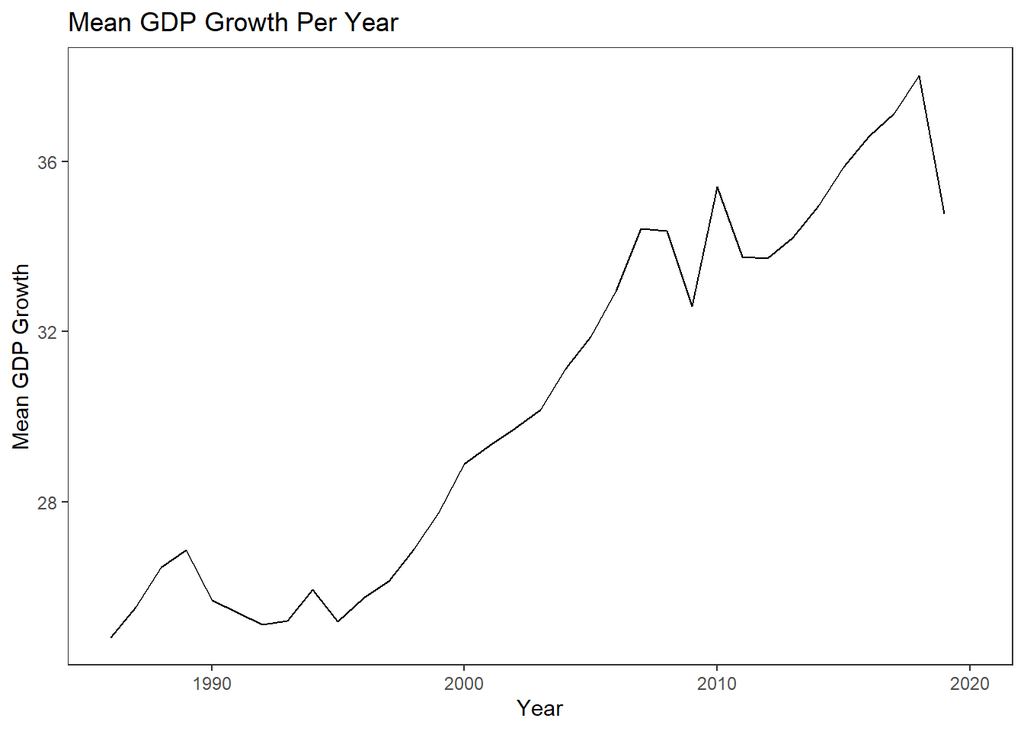

```r
ggplot(data = ggdata, aes(x=year,y=gdp_mean)) +
  geom_line() +
  xlab("Year")+
  ylab("Mean GDP Growth")+
  ggtitle("Mean GDP Growth Per Year")+
  theme_bw()+
  theme(panel.grid = element_blank())
```

### Question 4 part 2

Now, let’s plot GDP and Gini coefficients on the same plot. Start with the plot above (I would copy and paste the code as a starting point), and add another lineplot for gini. In addition to the above plot improvements, also differentiate these two variables via separate colors or linetypes, and remove the legend title.

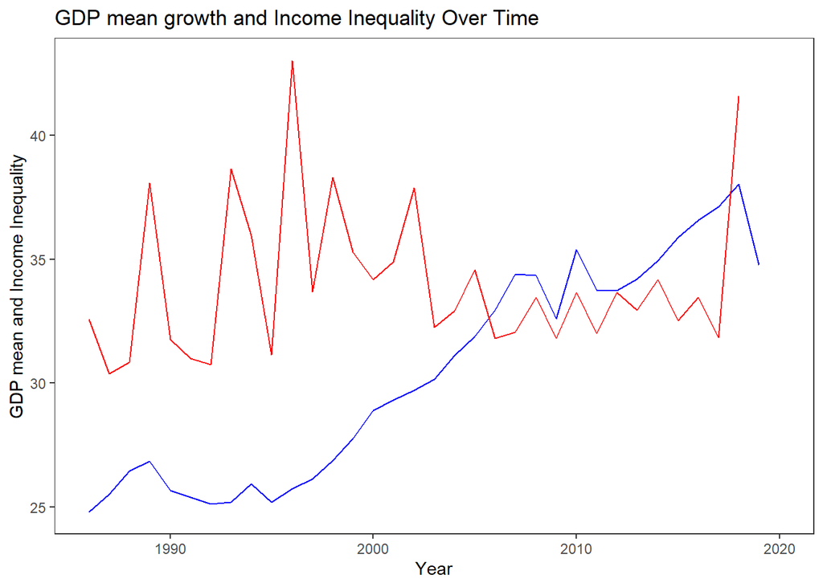

```r
ggplot(data= ggdata, aes(x=year)) +
  geom_line(aes(y=gdp_mean), color="blue") +
  geom_line(aes(y=gini_mean), color="red") +
  xlab("Year")+
  ylab("GDP mean and Income Inequality")+
  ggtitle("GDP mean growth and Income Inequality Over Time")+
  theme_bw()+
  theme(panel.grid = element_blank())
```

### Question 5 part 1

Finally, I would like to see what has an influence on highschool graduation rates. Build a regression model that assesses the impact of our two economic variables, gdp and gini, as well as literacy rate (as our three IVs) on highschool (our DV). Assign the model to some object, then use summary to view the results.

```r
model_highschool <- lm(highschool ~ gdp + gini +literacy, data = data)
summary(model_highschool)
```

```
##
## Call:
## lm(formula = highschool ~ gdp + gini + literacy, data = data)
##
## Residuals:
##     Min      1Q  Median      3Q     Max
## -29.023  -8.816  -4.213   6.428  38.154
##
## Coefficients:
##              Estimate Std. Error t value Pr(>|t|)
## (Intercept) -163.6667    46.1689  -3.545 0.000851 ***
## gdp           -0.8451     0.2743  -3.081 0.003324 **
## gini          -1.0353     0.3105  -3.335 0.001597 **
## literacy       2.7763     0.4692   5.917 2.76e-07 ***
## ---
## Signif. codes:  0 '***' 0.001 '**' 0.01 '*' 0.05 '.' 0.1 ' ' 1
##
## Residual standard error: 14.66 on 51 degrees of freedom
##   (2395 observations deleted due to missingness)
## Multiple R-squared:  0.5025, Adjusted R-squared:  0.4732
## F-statistic: 17.17 on 3 and 51 DF,  p-value: 7.736e-08
```

### Question 5 part 2

Explain in one sentence the direction of each of our three IVs relationships. Which relationships are significant?

*The gdp and gini relationships are negative while the literacy relationship is positive. All of the relationships are significant beacause their p-values are smaller than 0.05 and they all have stars next to them as well.*

### Question 5 part 3

For every additional one percent of the population that is literate, how will highschool graduation rate change?

*For every one percent of the population that is literate the high school graduation rate will increase by 2.77 which is great!*